# submission2

# Can we identify any trends in content production based on the release year vs. the year added to Netflix?

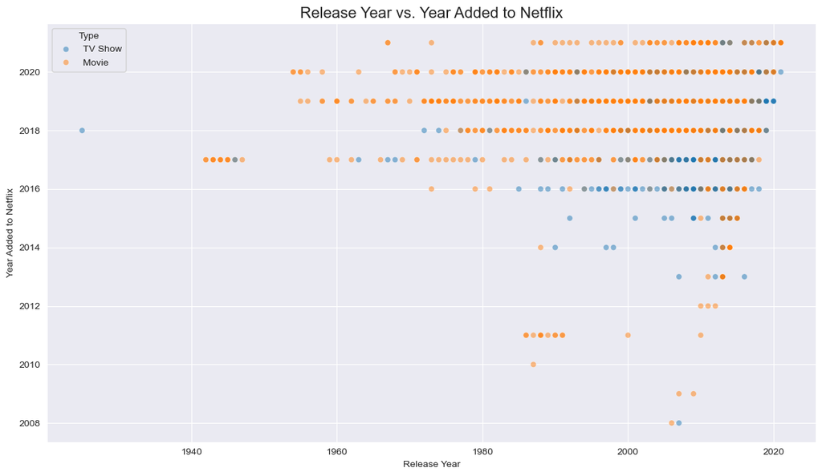

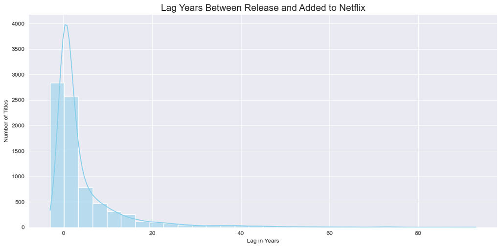

```python
# Ensure date_added is datetime
netflix_df['date_added'] = pd.to_datetime(netflix_df['date_added'], errors='coerce')

# Extract year_added
netflix_df['year_added'] = netflix_df['date_added'].dt.year

# Drop missing values
trend_data = netflix_df.dropna(subset=['release_year', 'year_added'])

# years between release and added to Netflix
trend_data['lag_years'] = trend_data['year_added'] - trend_data['release_year']

# Scatter of release vs. added year
plt.figure(figsize=(12, 7))
sns.scatterplot(data=trend_data, x='release_year', y='year_added', hue='type', alpha=0.5)

plt.title("Release Year vs. Year Added to Netflix", fontsize=16)
plt.xlabel("Release Year")
plt.ylabel("Year Added to Netflix")
plt.legend(title="Type")
plt.tight_layout()
plt.show()

#Plot 2: Distribution of lag years
plt.figure(figsize=(12, 6))
sns.histplot(trend_data['lag_years'], bins=30, kde=True, color="skyblue")

plt.title("Lag Years Between Release and Added to Netflix", fontsize=16)
plt.xlabel("Lag in Years")
plt.ylabel("Number of Titles")
plt.tight_layout()
plt.show()
```

-The analysis shows that Netflix mainly focuses on adding recent content, with most titles from 2010 onward being added soon after their release, often within 0–5 years, reflecting the platform’s emphasis on new productions and quick acquisitions. Older movies and TV shows, especially those from the mid-20th century, appear less frequently and were typically added much later, indicating a selective approach to classics. Overall, the trend highlights Netflix’s strategy of prioritizing fresh content while occasionally supplementing its library with older titles to diversify its offerings.

# What are the most common word pairs or phrases in content descriptions?

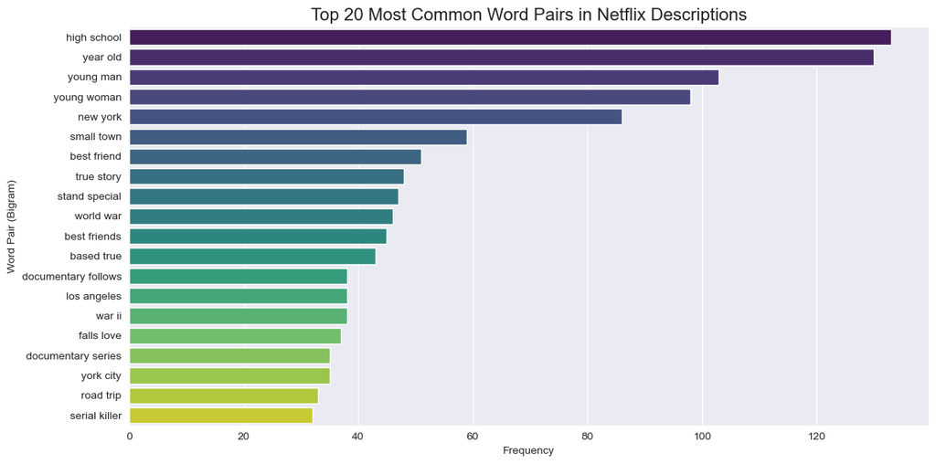

```python
from sklearn.feature_extraction.text import CountVectorizer
from collections import Counter

# Drop NA in description
descriptions = netflix_df['description'].dropna()

# Use CountVectorizer to extract bigrams
vectorizer = CountVectorizer(ngram_range=(2, 2), stop_words='english')
X = vectorizer.fit_transform(descriptions)

# Count bigram frequencies
bigram_counts = X.sum(axis=0).A1
bigram_freq = list(zip(vectorizer.get_feature_names_out(), bigram_counts))
bigram_freq_sorted = sorted(bigram_freq, key=lambda x: x[1], reverse=True)[:20]  # top 20

# Convert to DataFrame for plotting
bigram_df = pd.DataFrame(bigram_freq_sorted, columns=['bigram', 'count'])

# Plot
plt.figure(figsize=(12, 6))
sns.barplot(data=bigram_df, x='count', y='bigram', palette="viridis")

plt.title("Top 20 Most Common Word Pairs in Netflix Descriptions", fontsize=16)
plt.xlabel("Frequency")
plt.ylabel("Word Pair (Bigram)")
plt.tight_layout()
plt.show()
```

as we can see "high school is most comman word pairs also the above is showing top twenty

# Who are the top directors on Netflix?

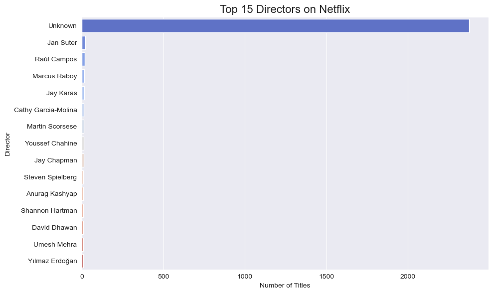

```python
directors_data = netflix_df.dropna(subset=['director'])

# Split multiple directors
directors_split = directors_data['director'].str.split(',').explode().str.strip()

# Count top directors
top_directors = directors_split.value_counts().head(15).reset_index()
top_directors.columns = ['director', 'count']

# Plot
plt.figure(figsize=(10, 6))
sns.barplot(data=top_directors, x='count', y='director', palette="coolwarm")

plt.title("Top 15 Directors on Netflix", fontsize=16)
plt.xlabel("Number of Titles")
plt.ylabel("Director")
plt.tight_layout()
plt.show()
```

Jan suter and raul are top known directors and rest of unknown